# Statistical Inference Course Project_Part 2

Shee

In the second part, we’re going to analyze the ToothGrowth data in the R datasets package.

### 1. Load the ToothGrowth data and perform some basic exploratory data analyses

```r
#Load the ToothGrowth data.
data(ToothGrowth)
ToothGrowth$dose <- as.factor(ToothGrowth$dose)

#Some basic exploratory data analyses.
str(ToothGrowth)
```

```
## 'data.frame':    60 obs. of  3 variables:
##  $ len : num  4.2 11.5 7.3 5.8 6.4 10 11.2 11.2 5.2 7 ...
##  $ supp: Factor w/ 2 levels "OJ","VC": 2 2 2 2 2 2 2 2 2 2 ...
##  $ dose: Factor w/ 3 levels "0.5","1","2": 1 1 1 1 1 1 1 1 1 1 ...
```

```r
head(ToothGrowth)
```

```
##    len supp dose
## 1  4.2   VC  0.5
## 2 11.5   VC  0.5
## 3  7.3   VC  0.5
## 4  5.8   VC  0.5
## 5  6.4   VC  0.5
## 6 10.0   VC  0.5
```

### 2. Basic summary of the data

The ToothGrowth dataset explains the relation between the growth of teeth of guinea pigs at each of three dose levels of Vitamin C (0.5, 1 and 2 mg) with each of two delivery methods(orange juice and ascorbic acid).

```r
summary(ToothGrowth)
```

```
##       len        supp     dose
##  Min.   : 4.20   OJ:30   0.5:20
##  1st Qu.:13.07   VC:30   1  :20
##  Median :19.25           2  :20
##  Mean   :18.81
##  3rd Qu.:25.27
##  Max.   :33.90
```

```r
table(ToothGrowth$supp, ToothGrowth$dose)
```

```
##
##      0.5  1  2
##   OJ  10 10 10
##   VC  10 10 10
```

```r
#Mean (by dose and by OJ & VC).
aggregate(ToothGrowth$len,list(ToothGrowth$supp,ToothGrowth$dose),mean)
```

```
##   Group.1 Group.2     x
## 1      OJ     0.5 13.23
## 2      VC     0.5  7.98
## 3      OJ       1 22.70
## 4      VC       1 16.77
## 5      OJ       2 26.06
## 6      VC       2 26.14
```

```r
#Standard Deviation (by dose and by OJ & VC).
aggregate(ToothGrowth$len,list(ToothGrowth$supp,ToothGrowth$dose),sd)
```

```
##   Group.1 Group.2        x
## 1      OJ     0.5 4.459709
## 2      VC     0.5 2.746634
## 3      OJ       1 3.910953
## 4      VC       1 2.515309
## 5      OJ       2 2.655058
## 6      VC       2 4.797731
```

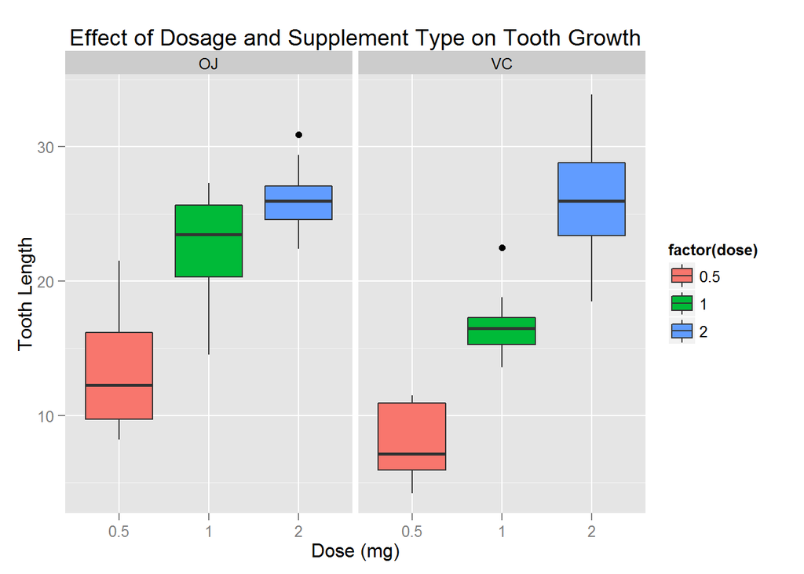

```r
#Boxplot graph of the tooth length on the dose.
library(ggplot2)
ggplot(ToothGrowth, aes(x = factor(dose), y = len, fill = factor(dose))) +
       geom_boxplot() + facet_grid(.~supp) +
       labs(title = "Effect of Dosage and Supplement Type on Tooth Growth",
       x = "Dose (mg)", y = "Tooth Length")
```

From the boxplot, the length of the tooth increases while the dosage level increases.

### 3. Use confidence intervals and/or hypothesis tests to compare tooth growth by supp and dose.

```r
# T-test by supplemant type
t.test(len ~ supp, data = ToothGrowth)
```

```
##
##  Welch Two Sample t-test
##
## data:  len by supp
## t = 1.9153, df = 55.309, p-value = 0.06063
## alternative hypothesis: true difference in means is not equal to 0
## 95 percent confidence interval:
##  -0.1710156  7.5710156
## sample estimates:
## mean in group OJ mean in group VC
##         20.66333         16.96333
```

```r
# T-test by dose level
Tooth_dose0510 <- subset(ToothGrowth, dose %in% c(0.5, 1.0))
Tooth_dose0520 <- subset(ToothGrowth, dose %in% c(0.5, 2.0))
Tooth_dose1020 <- subset(ToothGrowth, dose %in% c(1.0, 2.0))
t.test(len ~ dose, data = Tooth_dose0510)
```

```
##
##  Welch Two Sample t-test
##
## data:  len by dose
## t = -6.4766, df = 37.986, p-value = 1.268e-07
## alternative hypothesis: true difference in means is not equal to 0
## 95 percent confidence interval:
##  -11.983781  -6.276219
## sample estimates:
## mean in group 0.5   mean in group 1
##            10.605            19.735
```

```r
t.test(len ~ dose, data = Tooth_dose0520)
```

```
##
##  Welch Two Sample t-test
##
## data:  len by dose
## t = -11.799, df = 36.883, p-value = 4.398e-14
## alternative hypothesis: true difference in means is not equal to 0
## 95 percent confidence interval:
##  -18.15617 -12.83383
## sample estimates:
## mean in group 0.5   mean in group 2
##            10.605            26.100
```

```r
t.test(len ~ dose, data = Tooth_dose1020)
```

```
##
##  Welch Two Sample t-test
##
## data:  len by dose
## t = -4.9005, df = 37.101, p-value = 1.906e-05
## alternative hypothesis: true difference in means is not equal to 0
## 95 percent confidence interval:
##  -8.996481 -3.733519
## sample estimates:
## mean in group 1 mean in group 2
##          19.735          26.100
```

```r
# T-test for supplement by dose level
Tooth_dose05 <- subset(ToothGrowth, dose == 0.5)
Tooth_dose10 <- subset(ToothGrowth, dose == 1.0)
Tooth_dose20 <- subset(ToothGrowth, dose == 2.0)
t.test(len ~ supp, data = Tooth_dose05)
```

```
##
##  Welch Two Sample t-test
##
## data:  len by supp
## t = 3.1697, df = 14.969, p-value = 0.006359
## alternative hypothesis: true difference in means is not equal to 0
## 95 percent confidence interval:
##  1.719057 8.780943
## sample estimates:
## mean in group OJ mean in group VC
##            13.23             7.98
```

```r
t.test(len ~ supp, data = Tooth_dose10)
```

```
##
##  Welch Two Sample t-test
##
## data:  len by supp
## t = 4.0328, df = 15.358, p-value = 0.001038
## alternative hypothesis: true difference in means is not equal to 0
## 95 percent confidence interval:
##  2.802148 9.057852
## sample estimates:
## mean in group OJ mean in group VC
##            22.70            16.77
```

```r
t.test(len ~ supp, data = Tooth_dose20)
```

```
##
##  Welch Two Sample t-test
##
## data:  len by supp
## t = -0.0461, df = 14.04, p-value = 0.9639
## alternative hypothesis: true difference in means is not equal to 0
## 95 percent confidence interval:
##  -3.79807  3.63807
## sample estimates:
## mean in group OJ mean in group VC
##            26.06            26.14
```

For dose 0.5, the p-value of OJ compared to VC is 0.006359, which is less than 0.05, we reject null hypothesis, there is a difference between both methods.

For dose 1.0, the p-value of OJ compared to VC is 0.001038, which is less than 0.05, we reject null hypothesis, there is a difference between both methods.

For dose 2.0, the p-value of OJ compared to VC is 0.9639, which is greater than 0.05, we failed to reject null hypothesis, there is no significant difference between both methods.

### 4. Conclusions and Assumptions

Based of the results, we can conclude that:

1. The 2mg dose has larger impact on tooth growth than 1.0mg and 0.5mg, so there is a difference in the tooth growth while the doses are larger.
2. For doses of 0.5mg and 1.0mg, OJ has a greater effect on tooth growth than VC.
3. For dose 2.0mg there is no significant difference between the methods, thus it is uncertain whether there will be a greater effect for tooth growth from either OJ or VC.

Assumption: There is no other factor that will affect the tooth growth.